# Species presence along the estuary-sea continuum

The goal of this notebook is to find the set of environmental variables that describe the continuum from the estuary to the sea and capture the variations of species presence along it, as D11 did for the river. This continuum is the baseline on which stressors (nutrients, land use, upstream dams) are added later (catchment of each estuary: D20).

This notebook uses the POMET survey only (estuaries), where salinity, temperature and depth are measured at each haul. The next notebook (D21) extends the model to the nursery survey of the coastal bays.

Steps: (1) the data: fishing operations and species; (2) the environmental variables of the continuum; (3) presence models of the species and their diagnostics, as in D12; (4) the river nutrient inputs of each estuary, the first stressor added on top of this baseline, and their effect on presence.

**Candidate variables.**

| Variable | Source | Gradient it describes |
| --- | --- | --- |
| Salinity | Measured at the operation | Freshwater to marine |
| Distance to the river mouth | D8, along the river network (inland) or along the sea (at sea) | Position along the continuum |
| Depth | Measured at the operation | Shallow flats and channels to open water |
| Water temperature | Measured at the operation | Season, north-south, along the estuary |
| Oxygen | Measured at the operation (% saturation) | Water quality |
| Substrate | EMODnet Geology, seabed substrate 1:250,000 (Folk classes) | Mud to sand, gravel and rock |

## Setup

```r
library(renv)
renv::load()
```

```
- The project is out-of-sync -- use `renv::status()` for details.
```

```r
library(targets)
library(here)
tar_config_set(
  store = here::here("_targets")
)
library(ggplot2)
library(dplyr)
devtools::load_all()
nice_theme()
```

```r
guild_label <- c(
  MS = "Marine straggler", MM = "Marine migrant (juveniles)", ER = "Estuarine resident",
  CA = "Diadromous", FW = "Freshwater"
)
colour_guild <- c(
  `Marine straggler` = "#56B4E9", `Marine migrant (juveniles)` = "#0072B2",
  `Estuarine resident` = "#009E73", Diadromous = "#E69F00", Freshwater = "#CC79A7"
)
colour_district <- c(Seine = "#0072B2", `Escaut-Somme` = "#56B4E9", Loire = "#009E73", `Ardour-Garonne` = "#E69F00")
```

## Data

POMET is the beam trawl survey of the estuaries for the Water Framework Directive. We keep all its operations in the four districts, from the mouth to the upper estuaries, with their distance to the river mouth (D8; target `sea_operation`, POMET operations).

```r
operation <- filter(tar_read(sea_operation), survey == "pomet")
catch <- tar_read(sea_catch)
operation |>
  summarise(
    Operations = n(),
    Years = paste(min(year), max(year), sep = "-"),
    Months = paste(sort(unique(month)), collapse = ", "),
    `Salinity measured` = scales::percent(mean(salinity_source == "measured", na.rm = TRUE), 1),
    `Salinity from the grid` = scales::percent(mean(salinity_source == "grid", na.rm = TRUE), 1),
    `No salinity` = sum(is.na(salinity)),
    .by = gear
  ) |>
  rename(Gear = gear) |>
  knitr::kable()
```

| Gear | Operations | Years | Months | Salinity measured | Salinity from the grid | No salinity |
| --- | --- | --- | --- | --- | --- | --- |
| beam trawl 1.46m | 4479 | 2005-2019 | 4, 5, 6, 7, 8, 9, 10, 11 | 99% | 1% | 118 |
| beam trawl 3m | 2283 | 2005-2018 | 4, 5, 6, 7, 8, 9, 10, 11 | 98% | 2% | 61 |

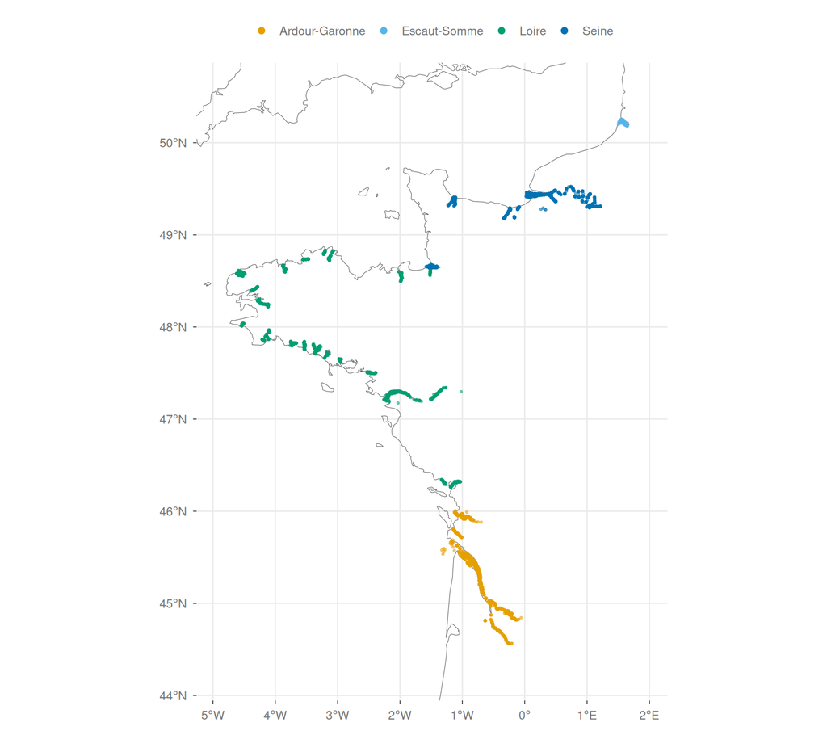

POMET operations in the four districts.

```r
coast <- coastline()
ggplot() +
  geom_sf(data = coast, color = "grey40", linewidth = 0.2) +
  geom_point(
    aes(longitude, latitude, color = district),
    data = operation, size = 0.6, alpha = 0.5
  ) +
  coord_sf(xlim = range(operation$longitude) + c(-0.3, 0.3), ylim = range(operation$latitude) + c(-0.3, 0.3)) +
  scale_color_manual(values = colour_district) +
  labs(x = NULL, y = NULL, color = NULL) +
  guides(color = guide_legend(override.aes = list(size = 2, alpha = 1))) +
  theme(legend.position = "top", axis.line = element_blank())
```

### Species and guilds

Each species is classed by its use of estuaries, from the guilds of the POMET reference (target `estuary_guild`), matched on the names validated against FishBase (the reference uses older names, e.g. *Liza ramada* for *Chelon ramada*), completed by hand for the species missing from it and corrected by hand for a few (target `species_guild`, notes in the table below).

The five guilds are the estuarine-use functional groups of Elliott and Quintino (2007).

[output not shown]

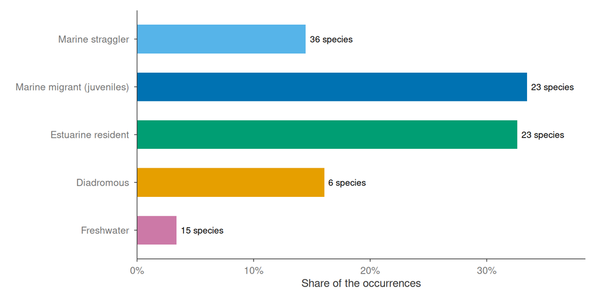

Share of the occurrences (species x operation) of each guild, and number of species.

```r
catch |>
  semi_join(operation, by = "operation_id") |>
  mutate(guild = factor(coalesce(guild_label[guild], "Unclassified"), rev(c(guild_label, "Unclassified")))) |>
  summarise(species = n_distinct(species), occurrences = n(), .by = guild) |>
  mutate(share = occurrences / sum(occurrences)) |>
  ggplot(aes(share, guild, fill = guild)) +
  geom_col(width = 0.6, show.legend = FALSE) +
  geom_text(aes(label = paste(species, "species")), hjust = -0.1, size = 3) +
  scale_fill_manual(values = c(colour_guild, Unclassified = "grey70")) +
  scale_x_continuous(labels = scales::percent, expand = expansion(mult = c(0, 0.15))) +
  labs(x = "Share of the occurrences", y = NULL) +
  theme(panel.grid.major.y = element_blank())
```

```r
species_guild <- tar_read(species_guild)
catch |>
  semi_join(operation, by = "operation_id") |>
  count(species) |>
  inner_join(species_guild, by = "species") |>
  mutate(guild = factor(guild_label[guild], guild_label)) |>
  arrange(guild, desc(n)) |>
  transmute(
    Species = paste0("*", species, "*"), Guild = guild, Operations = n,
    `Guild source` = source, Note = coalesce(note, "")
  ) |>
  knitr::kable()
```

| Species | Guild | Operations | Guild source | Note |
| --- | --- | --- | --- | --- |
| *Callionymus lyra* | Marine straggler | 868 | POMET reference |  |
| *Echiichthys vipera* | Marine straggler | 551 | POMET reference |  |
| *Aphia minuta* | Marine straggler | 502 | POMET reference |  |
| *Buglossidium luteum* | Marine straggler | 311 | POMET reference |  |
| *Ammodytes tobianus* | Marine straggler | 273 | POMET reference |  |
| *Atherina presbyter* | Marine straggler | 256 | POMET reference |  |
| *Arnoglossus laterna* | Marine straggler | 184 | POMET reference |  |
| *Pegusa lascaris* | Marine straggler | 136 | POMET reference |  |
| *Spondyliosoma cantharus* | Marine straggler | 132 | POMET reference |  |
| *Raja clavata* | Marine straggler | 127 | POMET reference |  |
| *Labrus bergylta* | Marine straggler | 124 | POMET reference |  |
| *Ctenolabrus rupestris* | Marine straggler | 113 | POMET reference |  |
| *Mullus surmuletus* | Marine straggler | 113 | POMET reference |  |
| *Arnoglossus thori* | Marine straggler | 98 | POMET reference |  |
| *Trisopterus minutus* | Marine straggler | 75 | POMET reference |  |
| *Agonus cataphractus* | Marine straggler | 63 | POMET reference |  |
| *Hyperoplus lanceolatus* | Marine straggler | 57 | POMET reference |  |
| *Zeus faber* | Marine straggler | 49 | POMET reference |  |
| *Taurulus bubalis* | Marine straggler | 41 | POMET reference |  |
| *Conger conger* | Marine straggler | 39 | POMET reference |  |
| *Raja undulata* | Marine straggler | 38 | POMET reference |  |
| *Sparus aurata* | Marine straggler | 28 | POMET reference |  |
| *Umbrina canariensis* | Marine straggler | 23 | POMET reference |  |
| *Eutrigla gurnardus* | Marine straggler | 20 | POMET reference |  |
| *Merluccius merluccius* | Marine straggler | 18 | POMET reference |  |
| *Chelidonichthys lastoviza* | Marine straggler | 15 | added by hand | Marine species, occasional in estuaries |
| *Dicologlossa cuneata* | Marine straggler | 15 | POMET reference |  |
| *Entelurus aequoreus* | Marine straggler | 15 | POMET reference |  |
| *Diplodus sargus* | Marine straggler | 14 | POMET reference |  |
| *Microchirus variegatus* | Marine straggler | 14 | POMET reference |  |

[output cut: 73 more lines]

## Environmental variables

```r
seabed <- tar_read(sea_operation_seabed)
operation_env <- operation |>
  left_join(seabed, by = "operation_id") |>
  mutate(
    position = if_else(inland, "Inland (upper estuary)", "At sea"),
    distance_km = dist_mouth_m / 1000
  )
colour_substrate <- c(mud = "#8C510A", sand = "#DFC27D", coarse = "#35978F", rock = "#525252", unmapped = "grey80")
```

Substrate and depth are taken from EMODnet, the European Marine Observation and Data Network, which compiles the national marine data (SHOM, Ifremer, BRGM for France). Target `sea_operation_seabed`.

- **Substrate:** EMODnet Geology seabed substrate at 1:250,000, the substrate class of the polygon containing the operation. We use the five Folk classes of EMODnet (mud to muddy sand, sand, coarse-grained, mixed, rock and boulders), with coarse and mixed sediment merged: mud, sand, coarse, rock. Operations outside the polygons are “unmapped”. The EUSeaMap habitat map gives the same classes where both exist (it is built from them), and the SHOM 1:50,000 seabed map covers the same areas, so neither is used.
- **Depth:** measured at the hauls (water depth, tide included). EMODnet Bathymetry (2022, ~115 m, depth below the lowest astronomical tide) is not used: its cells miss the narrow estuary channels, so 58% of the operations fall on cells above the lowest tide, and its rank correlation with the measured depth is only 0.43 (it is also shallower by about the tidal range). The depth of the yearly modelled grid follows EMODnet and hardly covers the estuaries.

Maps of the study coast (`map_coast()` below): the operations over the substrate polygons, then coloured by salinity and by distance to the mouth.

```r
substrate_polygon <- purrr::map(tar_read(emodnet_substrate_file), sf::st_read, quiet = TRUE) |>
  dplyr::bind_rows() |>
  mutate(substrate = folk_substrate(folk_5cl_txt))
map_coast <- \(layer, scale) {
  ggplot() +
    layer +
    geom_sf(data = coast, color = "grey30", linewidth = 0.2) +
    geom_point(aes(longitude, latitude, color = .data$value), data = operation_env, size = 0.5) +
    coord_sf(
      xlim = range(operation_env$longitude) + c(-0.2, 0.2),
      ylim = range(operation_env$latitude) + c(-0.2, 0.2)
    ) +
    scale +
    labs(x = NULL, y = NULL) +
    theme(legend.position = "top", axis.line = element_blank())
}
```

### Substrate

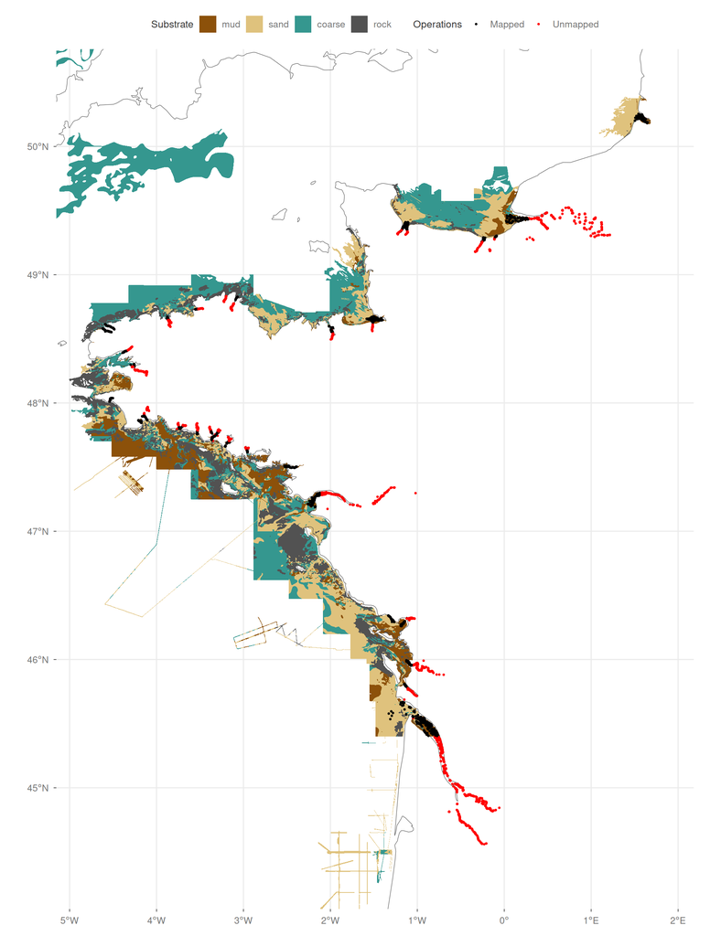

EMODnet substrate (polygons) and the operations (black: inside a polygon, red: unmapped).

```r
operation_env <- mutate(operation_env, value = if_else(substrate == "unmapped", "Unmapped", "Mapped"))
map_coast(
  geom_sf(aes(fill = substrate), data = substrate_polygon, color = NA),
  scale_color_manual(values = c(Mapped = "black", Unmapped = "red"), name = "Operations")
) +
  scale_fill_manual(values = colour_substrate[1:4], name = "Substrate")
```

**Results:**

- At sea (downstream of the river mouth), 86% of the operations have a substrate.
- 72% of the inland operations are unmapped: the marine maps stop where the estuary narrows into the river channel.
- Unmapped operations are the low-salinity end of the continuum: 97% of the operations below salinity 5 are unmapped.

*To discuss:*

- The “unmapped” level overlaps with low salinity and the upstream distances, so its coefficient will partly carry their effect; it has no meaning about substrate.

### Salinity

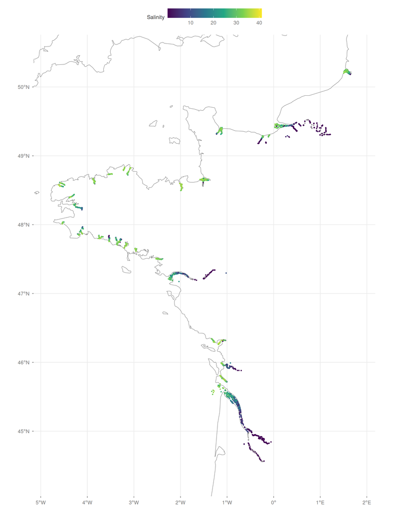

Salinity measured at the operations (a few from the yearly grid); grey: missing.

```r
operation_env <- mutate(operation_env, value = salinity)
map_coast(
  NULL,
  scale_color_viridis_c(
    name = "Salinity", limits = range(operation_env$value, na.rm = TRUE),
    na.value = "grey60", guide = guide_colorbar(barwidth = 12)
  )
)
```

**Results:**

- Salinity falls from about 33 at sea to fresh water upstream in the large estuaries (Seine, Loire, Gironde); the short Breton estuaries stay mostly brackish to marine.

### Distance to the mouth

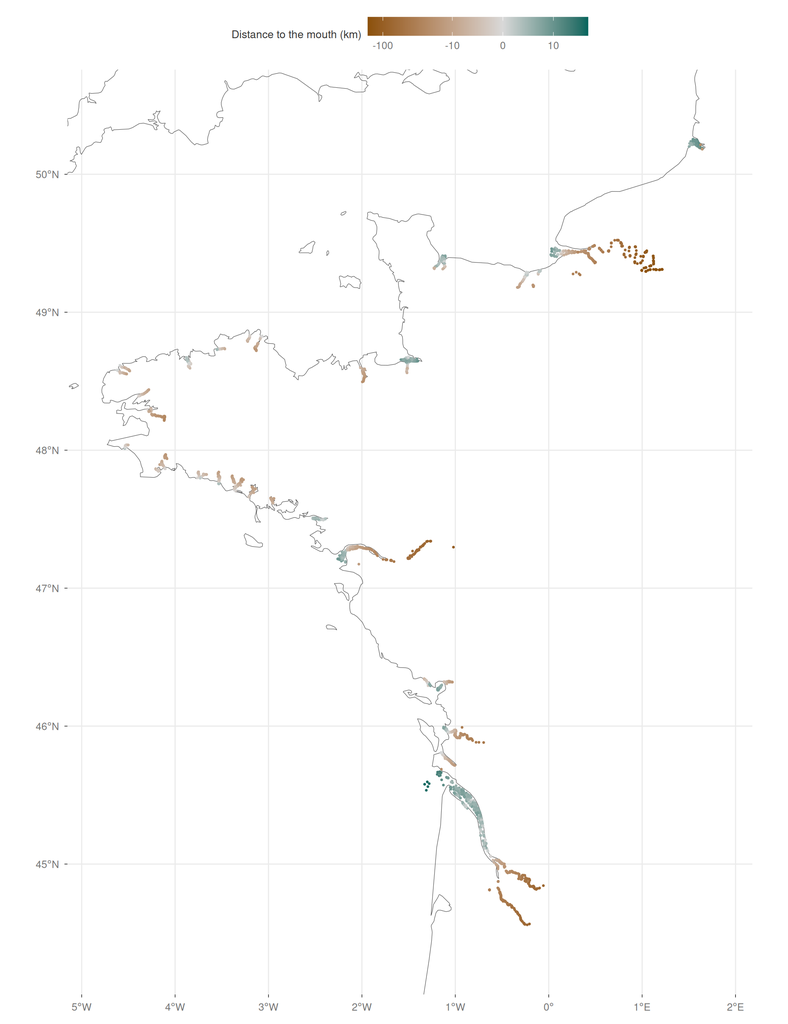

Distance of the operations to the river mouth (km; negative upstream, along the river; positive at sea; pseudo-log colour scale).

```r
operation_env <- mutate(operation_env, value = distance_km)
pseudo_log <- scales::transform_pseudo_log(sigma = 2) # spreads the many operations near the mouth
distance_range <- range(operation_env$value, na.rm = TRUE)
map_coast(
  NULL,
  scale_color_gradientn(
    colours = c("#8C510A", "grey85", "#01665E"),
    values = scales::rescale(pseudo_log$transform(c(distance_range[1], 0, distance_range[2]))),
    limits = distance_range, transform = pseudo_log, breaks = c(-100, -10, 0, 10, 50),
    name = "Distance to the mouth (km)", na.value = "grey60", guide = guide_colorbar(barwidth = 14)
  )
)
```

**Results:**

- Half of the operations lie within 7 km of the mouth; the longest upstream distances are in the Seine, Loire and Garonne-Dordogne.
- In the Gironde, the estuary counts as “at sea” (positive distances, 0 to 10 km): AMOBIO’s Gironde ends at the head of the estuary (Bec d’Ambès). Kept: the Gironde estuary is much larger than the Loire and Seine ones, so sea conditions reach further inside.

## Presence models (POMET)

Every variable is measured at the haul, from a single source (salinity, water temperature, oxygen and depth), plus the distance to the mouth and the EMODnet substrate.

We test two common species living at the two ends of the continuum:

- the **common sole** (*Solea solea*, marine migrant), whose juveniles grow in shallow coastal and estuarine nurseries;
- the **European flounder** (*Platichthys flesus*, diadromous), whose juveniles use the low-salinity upper estuaries.

```r
presence_visit <- tar_read(sea_presence_visit)
pomet_visit <- tar_read(pomet_presence_visit)
pomet_model <- tar_read(pomet_presence_model)
pomet_water <- tar_read(pomet_water)
pomet_oxygen <- unlist(tar_read(pomet_oxygen_model), recursive = FALSE)
test_species <- c("Solea solea", "Platichthys flesus")
pomet_of <- \(species, variant) pomet_model[[which(purrr::map_lgl(
  pomet_model, \(m) m$species == species && m$variant == variant
))]]
# WAIC difference of a variant to the reference model.
dwaic <- \(species, variant) pomet_of(species, variant)$waic - pomet_of(species, "reference")$waic
auc <- \(score, present) {
  r <- rank(score)
  n1 <- sum(present)
  (sum(r[present == 1]) - n1 * (n1 + 1) / 2) / (n1 * (length(present) - n1))
}
pomet_label <- c(
  log_salinity = "Salinity (log)", log_salinity2 = "Salinity (log)²",
  distance = "Distance to the mouth", depth_pomet = "Depth", temperature = "Temperature",
  oxygen = "Oxygen", substratesand = "Sand (vs mud)", substratecoarse = "Coarse (vs mud)",
  substraterock = "Rock (vs mud)", substrateunmapped = "Unmapped (vs mud)"
)
pomet_all <- presence_visit |>
  filter(survey == "pomet") |>
  inner_join(pomet_water, by = "operation_id") |>
  left_join(transmute(operation, operation_id = as.character(operation_id), district), by = "operation_id")
```

### Temperature and oxygen

Temperature and oxygen are read from the POMET size file (`read_pomet_water()`, target `pomet_water`):

- **Temperature:** one impossible value (47.4 °C) set to missing.
- **Oxygen:** set to missing in the campaigns (zone, year and month) where every haul is below 20% saturation: about 240 hauls of Brittany and Normandy bays and estuaries in 2010–2012 (Mont-Saint-Michel, Caen, Veys, Vilaine, Elorn, Aber Wrac’h), at near-marine salinity, with values around 3 or 6–12, while campaigns of the same zones in other months read around 100%. These look like another unit or a recording error rather than hypoxia. Isolated low values in campaigns with normal values (e.g. the Loire in July 2006) are kept as possible low-oxygen events.

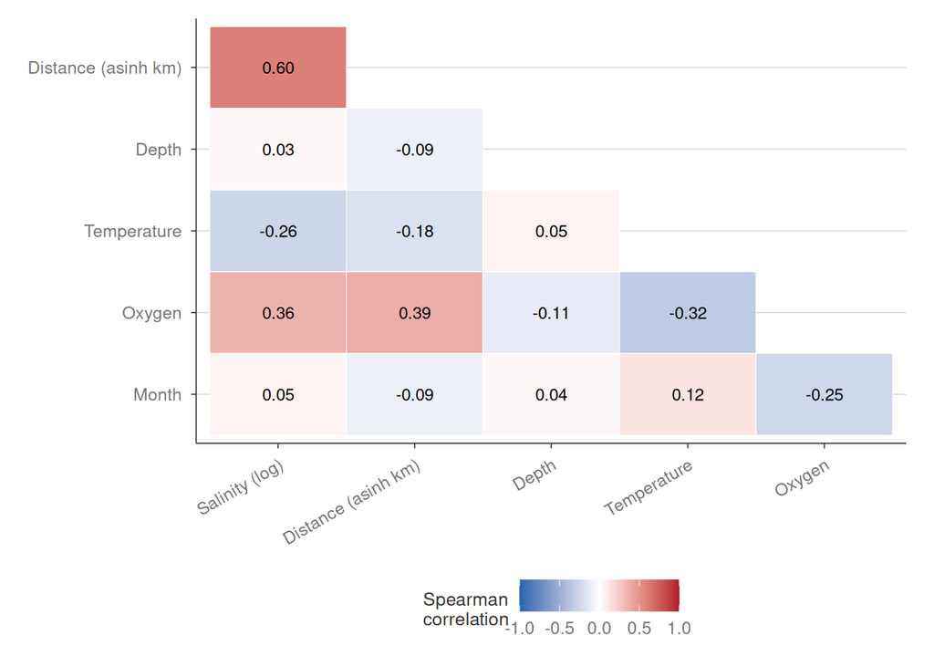

Pairwise Spearman correlations of the continuous variables at the POMET operations.

```r
pomet_variable <- pomet_all |>
  transmute(
    `Salinity (log)` = log_salinity, `Distance (asinh km)` = distance, Depth = depth_pomet,
    Temperature = temperature, Oxygen = oxygen, Month = month
  )
pomet_correlation <- cor(pomet_variable, method = "spearman", use = "pairwise.complete.obs")
as_tibble(pomet_correlation, rownames = "x") |>
  tidyr::pivot_longer(-x, names_to = "y", values_to = "rho") |>
  mutate(x = factor(x, colnames(pomet_correlation)), y = factor(y, rev(colnames(pomet_correlation)))) |>
  filter(as.integer(x) < ncol(pomet_correlation) + 1 - as.integer(y)) |>
  ggplot(aes(x, y, fill = rho)) +
  geom_tile(color = "white") +
  geom_text(aes(label = sprintf("%.2f", rho)), size = 3.2) +
  scale_fill_gradient2(low = "#2166AC", high = "#B2182B", limits = c(-1, 1)) +
  labs(x = NULL, y = NULL, fill = "Spearman\ncorrelation") +
  theme(axis.text.x = element_text(angle = 30, hjust = 1), panel.grid = element_blank())
```

**Results:**

### Model design

Bernoulli model with logit link of the presence of a species at an operation (`fit_sea_presence_model()`, INLA):

- **Continuum effects:** log(1 + salinity) and its square, distance to the mouth (signed, `asinh(km)`), depth and temperature, all standardised. Linear terms; a square is kept only where it clearly improves the fit.
- **Sampling effects:** gear (1.46 m and 3 m beam trawls) and month (reference: September).
- **Random effects:** year (iid) and a Matérn spatial field (SPDE, mesh edges up to 10 km; prior: range below 20 km with probability 0.5). No zone effect: the field takes the differences between zones.
- Fitted without INLA’s variational Bayes correction: with it, the correction diverged for the sole and its WAIC varied by about 100 points between identical refits; without it, refits agree.
- Effects shown with 91% credible intervals.

Variants change one term of the reference at a time (target `pomet_presence_model`, 6364 operations with a temperature). They are compared with the WAIC (lower is better).

### Variable selection

```r
purrr::map_dfr(pomet_model, \(m) tibble(species = m$species, variant = m$variant, waic = m$waic)) |>
  mutate(waic = waic - waic[variant == "reference"], .by = species) |>
  tidyr::pivot_wider(names_from = species, values_from = waic, names_glue = "ΔWAIC, {species}") |>
  rename(Variant = variant) |>
  knitr::kable(digits = 1, caption = "Difference to the reference model of each species (negative: better than the reference; differences below ~10 are small).")
```

Difference to the reference model of each species (negative: better than the reference; differences below ~10 are small).

| Variant | ΔWAIC, Solea solea | ΔWAIC, Platichthys flesus |
| --- | --- | --- |
| reference | 0.0 | 0.0 |
| linear log salinity | 10.5 | 2.7 |
| quadratic temperature | 1.1 | -2.4 |
| no temperature | 16.3 | 8.9 |
| no distance | 0.6 | 2.6 |
| no depth | 1.0 | 17.9 |
| with substrate | 3.0 | 5.7 |
| no field | 1767.5 | 1771.1 |

Oxygen is tested on the 5567 operations with oxygen (target `pomet_oxygen_model`).

```r
purrr::map_dfr(pomet_oxygen, \(m) {
  effect <- if ("oxygen" %in% rownames(m$summary.fixed)) m$summary.fixed["oxygen", ] else NULL
  tibble(
    species = m$species, variant = m$variant, waic = m$waic,
    effect = if (is.null(effect)) NA else sprintf("%.2f [%.2f, %.2f]", effect$mean, effect$`0.045quant`, effect$`0.955quant`)
  )
}) |>
  mutate(waic = waic - waic[variant == "without oxygen"], .by = species) |>
  mutate(species = paste0("*", species, "*")) |>
  rename(Species = species, Variant = variant, `ΔWAIC` = waic, `Oxygen effect (linear term)` = effect) |>
  knitr::kable(digits = 1, caption = "Oxygen test: difference to the reference model without oxygen (negative: better), and oxygen effect (logit, standardised, 91% credible interval).")
```

Oxygen test: difference to the reference model without oxygen (negative: better), and oxygen effect (logit, standardised, 91% credible interval).

| Species | Variant | ΔWAIC | Oxygen effect (linear term) |
| --- | --- | --- | --- |
| *Solea solea* | without oxygen | 0.0 | NA |
| *Solea solea* | with oxygen | 2.3 | -0.00 [-0.10, 0.10] |
| *Solea solea* | quadratic oxygen | 4.7 | -0.00 [-0.10, 0.10] |
| *Platichthys flesus* | without oxygen | 0.0 | NA |
| *Platichthys flesus* | with oxygen | 1.9 | 0.02 [-0.07, 0.10] |
| *Platichthys flesus* | quadratic oxygen | -2.2 | 0.01 [-0.07, 0.09] |

**Results:**

- **Temperature** improves both models (without it: +16.3 WAIC points for the sole, +8.9 for the flounder); its square adds nothing.
- **The square of log salinity** is needed for the sole (+10.5 without it), less for the flounder (+2.7).
- **Depth** matters for the flounder (+17.9 without it), hardly for the sole (+1.0).
- **Distance** changes the fit by a few points only (+0.6 and +2.6); kept, as it is credible for the flounder.
- **Substrate and oxygen do not improve the models** (substrate: +3.0 and +5.7 WAIC points; oxygen: 2–4 points, in both directions, with an effect close to 0): both are left out of the reference model. Leaving oxygen out also brings back the operations without oxygen.

*To discuss:*

- Substrate may still matter for other species; the upper estuaries are unmapped, so it can only act at the mouth and at sea.
- Oxygen is mostly between 77% and 100% saturation (quartiles) in these survey; the rare low values (upper Loire, Gironde) are too few to estimate an effect of low oxygen. It is a candidate stressor for later rather than a continuum variable.

### Effects

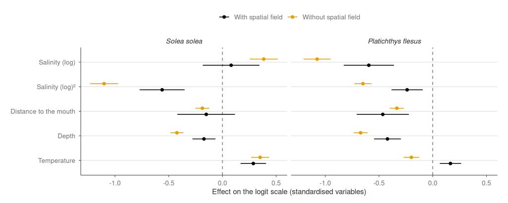

Effects of the continuum variables on presence (logit scale, standardised variables, 91% credible intervals), with and without the spatial field.

```r
purrr::map_dfr(test_species, \(s) {
  purrr::map_dfr(c("reference", "no field"), \(v) {
    as_tibble(pomet_of(s, v)$summary.fixed, rownames = "term") |>
      transmute(species = s, model = if_else(v == "no field", "Without spatial field", "With spatial field"),
                term, mean, lower = `0.045quant`, upper = `0.955quant`)
  })
}) |>
  filter(term %in% names(pomet_label)) |>
  mutate(term = factor(pomet_label[term], rev(pomet_label)), species = factor(species, test_species)) |>
  ggplot(aes(mean, term, color = model)) +
  geom_vline(xintercept = 0, linetype = "dashed", color = "grey50") +
  geom_pointrange(aes(xmin = lower, xmax = upper), size = 0.25, position = position_dodge(width = 0.5)) +
  facet_wrap(~species) +
  scale_color_manual(values = c(`With spatial field` = "black", `Without spatial field` = "#E69F00")) +
  labs(x = "Effect on the logit scale (standardised variables)", y = NULL, color = NULL) +
  theme(strip.text = element_text(face = "italic"), legend.position = "top")
```

Response curves: probability of presence along each variable, the others at their mean, at the reference sampling (1.46 m trawl, September) and at the average of the year and field effects over the operations.

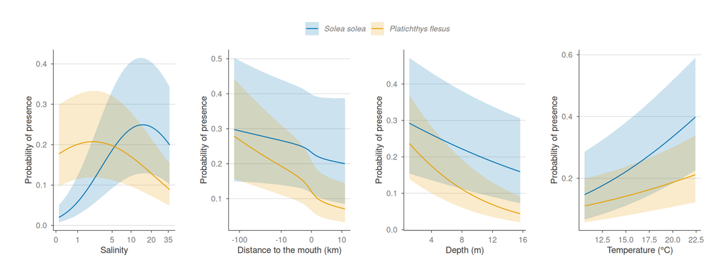

Probability of presence along each variable (reference model, 91% credible intervals).

```r
pomet_curve <- purrr::map_dfr(test_species, \(s) {
  m <- pomet_of(s, "reference")
  random_mean <- mean(m$prediction$eta - m$prediction$eta_fixed)
  mutate(m$curve, species = s, across(c(mean, lower, upper), \(x) plogis(x + random_mean)))
}) |>
  filter(variable != "substrate") |>
  mutate(
    species = factor(species, test_species),
    value = case_when(variable == "log_salinity" ~ expm1(value), variable == "distance" ~ sinh(value), .default = value)
  )
pomet_curve_plot <- \(v, label, scale_x = NULL) {
  ggplot(filter(pomet_curve, variable == v), aes(value, mean, color = species, fill = species)) +
    geom_ribbon(aes(ymin = lower, ymax = upper), alpha = 0.2, color = NA) +
    geom_line() +
    scale_x +
    scale_color_manual(values = c("#0072B2", "#E69F00"), aesthetics = c("color", "fill")) +
    labs(x = label, y = "Probability of presence", color = NULL, fill = NULL)
}
patchwork::wrap_plots(
  pomet_curve_plot("log_salinity", "Salinity", scale_x_continuous(transform = "log1p", breaks = c(0, 1, 5, 10, 20, 35))),
  pomet_curve_plot(
    "distance", "Distance to the mouth (km)",
    scale_x_continuous(transform = scales::transform_pseudo_log(sigma = 2), breaks = c(-100, -10, 0, 10))
  ),
  pomet_curve_plot("depth_pomet", "Depth (m)"),
  pomet_curve_plot("temperature", "Temperature (°C)"),
  nrow = 1, guides = "collect"
) & theme(legend.position = "top", legend.text = element_text(face = "italic"))
```

**Results:**

*To discuss:*

- **Spatial confounding.** With the field, the effects are smaller and less certain than without it: the field and the continuum variables share the differences between estuaries.
- **The flounder temperature effect changes sign with the field:** positive with it (0.16), negative without (-0.2). Temperature differs between estuaries: Ardour-Garonne is the warmest district (median 18.2 °C, against 15.8 °C in the Loire) and has few flounder. Without the field, this between-estuary difference goes into the temperature effect; with it, the effect rests mostly on the variation within estuaries (season, year, along the estuary).
- The temperature measured at the haul is a snapshot; part of its effect may be seasonal timing (juveniles arriving in late spring), not captured by the month effect alone.
- The models pool all sizes caught, while the literature describes juveniles; most sole and flounder caught by these beam trawls are likely juveniles, but this is not checked here.

### Diagnostics

```r
purrr::map_dfr(test_species, \(s) {
  m <- pomet_of(s, "reference")
  f <- pomet_of(s, "no field")
  continuum <- intersect(names(pomet_label), rownames(m$correlation))
  correlation <- m$correlation[continuum, continuum]
  tibble(
    Species = paste0("*", s, "*"),
    Operations = m$n,
    Prevalence = m$prevalence,
    `AUC, full model` = auc(m$prediction$eta, m$prediction$present),
    `AUC, fixed effects only` = auc(m$prediction$eta_fixed, m$prediction$present),
    `AUC, model without field` = auc(f$prediction$eta, f$prediction$present),
    `Field sd (logit)` = m$summary.hyperpar["Stdev for spatial", "mean"],
    `Field range (km)` = m$summary.hyperpar["Range for spatial", "mean"],
    `Max posterior correlation` = max(abs(correlation[upper.tri(correlation)]))
  )
}) |>
  knitr::kable(digits = 2, caption = "Diagnostics of the reference model (in-sample AUC; posterior correlation: largest between two continuum effects).")
```

Diagnostics of the reference model (in-sample AUC; posterior correlation: largest between two continuum effects).

| Species | Operations | Prevalence | AUC, full model | AUC, fixed effects only | AUC, model without field | Field sd (logit) | Field range (km) | Max posterior correlation |
| --- | --- | --- | --- | --- | --- | --- | --- | --- |
| *Solea solea* | 6364 | 0.39 | 0.91 | 0.74 | 0.80 | 2.15 | 27.33 | 0.62 |
| *Platichthys flesus* | 6364 | 0.36 | 0.89 | 0.70 | 0.75 | 1.99 | 23.80 | 0.77 |

Observed share of presences against the prediction, in cells of 0.05° (about 4–5 km), for two predictions: the continuum and sampling effects alone (fixed effects, at the average of the year and field effects), which shows what the continuum variables explain, and the full model with the field.

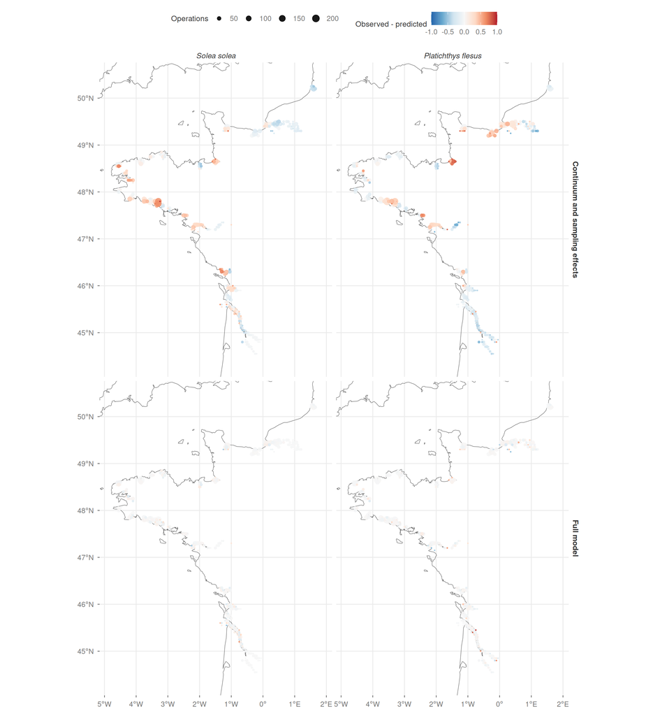

Observed share of presences minus predicted probability in cells of 0.05° (size: operations; red: more presences than predicted, blue: fewer). Top: continuum and sampling effects only; bottom: full model with the spatial field.

```r
pomet_cell <- purrr::map_dfr(test_species, \(s) {
  m <- pomet_of(s, "reference")
  random_mean <- mean(m$prediction$eta - m$prediction$eta_fixed)
  m$prediction |>
    inner_join(select(pomet_visit, operation_id, longitude, latitude), by = "operation_id") |>
    mutate(longitude = round(longitude / 0.05) * 0.05, latitude = round(latitude / 0.05) * 0.05) |>
    summarise(
      n = n(), observed = mean(present),
      `Continuum and sampling effects` = mean(plogis(eta_fixed + random_mean)), `Full model` = mean(plogis(eta)),
      .by = c(longitude, latitude)
    ) |>
    mutate(species = factor(s, test_species))
}) |>
  tidyr::pivot_longer(c(`Continuum and sampling effects`, `Full model`), names_to = "prediction", values_to = "predicted") |>
  mutate(residual = observed - predicted)
ggplot(arrange(pomet_cell, abs(residual))) +
  geom_sf(data = coast, color = "grey30", linewidth = 0.2) +
  geom_point(aes(longitude, latitude, color = residual, size = n), alpha = 0.9) +
  facet_grid(prediction ~ species) +
  coord_sf(xlim = range(pomet_visit$longitude) + c(-0.2, 0.2), ylim = range(pomet_visit$latitude) + c(-0.2, 0.2)) +
  scale_color_distiller(palette = "RdBu", limits = c(-1, 1), name = "Observed - predicted") +
  scale_size_area(max_size = 4, name = "Operations") +
  labs(x = NULL, y = NULL) +
  theme(strip.text.x = element_text(face = "italic"), axis.line = element_blank(), legend.position = "top")
```

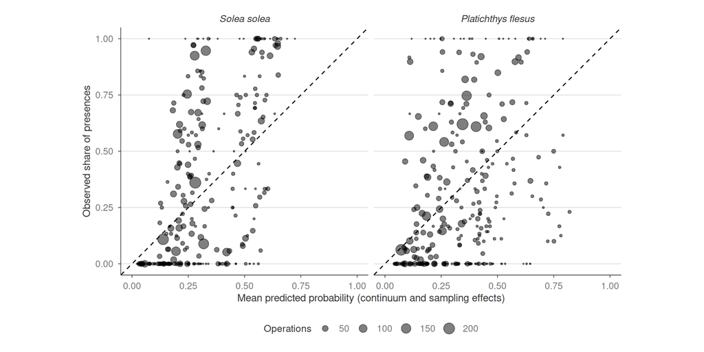

Observed share of presences against the mean predicted probability in cells of 0.05° (continuum and sampling effects only; size: operations; line: 1:1).

```r
pomet_cell |>
  filter(prediction == "Continuum and sampling effects") |>
  ggplot(aes(predicted, observed)) +
  geom_abline(linetype = "dashed") +
  geom_point(aes(size = n), alpha = 0.5) +
  facet_wrap(~species) +
  coord_equal(xlim = c(0, 1), ylim = c(0, 1)) +
  scale_size_area(max_size = 5, name = "Operations") +
  labs(x = "Mean predicted probability (continuum and sampling effects)", y = "Observed share of presences") +
  theme(strip.text = element_text(face = "italic"))
```

**Results:**

- **With the continuum and sampling effects alone,** the share of presences in a cell is off by 0.24 on average for the sole and 0.23 for the flounder (weighted by operations), and the errors are grouped by estuary rather than scattered: the gaps are between estuaries.
- **Under-predicted** (more presences than predicted) for both species: the small estuaries of southern Brittany (Blavet, Scorff, Laïta, Belon, Vilaine) and the Bay of Mont-Saint-Michel; for the flounder, also the Baie de Caen.
- **Over-predicted:** for the sole, the Somme bays (La Warenne à Ault: 4% observed, about 40% predicted), the freshwater Seine and the Baie de Caen; for the flounder, the upper Garonne, Isle and freshwater Seine, and the lower Gironde.
- **With the field,** the residuals are close to 0 everywhere (mean absolute error 0.03 and 0.03): the field takes these between-estuary differences. This is an in-sample fit; it does not say how a new estuary would be predicted.

*To discuss:*

- The between-estuary differences could come from estuary-level descriptors. Tested (targets `pomet_estuary_descriptor`, `pomet_estuary_model`): the POMET zones grouped into 29 estuaries, with their catchment area, the area of their WFD transitional water bodies and their type (estuary or bay). With the field, they do not improve the model (ΔWAIC within ±1, wide intervals); without the field they do (by about 270 and 320 WAIC points) but the model with the field stays much better. The baseline is the reference model with the field, without estuary descriptors.

## River inputs

Nutrients are the first stressor to add to the baseline. A presence model needs a value at each haul; this section builds it from the rivers flowing into each estuary: their yearly nutrient concentrations and oxygen saturation (NAIADES water quality stations), and their yearly discharge (HYDRO gauging stations).

**Why river inputs, and not the coastal nutrients of D7.** The REPHY model of D7 predicts nutrients at sea from coastal samples. Predicted at the POMET hauls, about 90% of its variation was already carried by the baseline (salinity, zone, year and month): the D7 model is a fixed spatial pattern plus a salinity effect and year and month effects shared by all places, which are all terms of the presence model. It is also least certain in the upper estuaries, where REPHY has few samples. It is not used here.

### Water quality: NAIADES river stations

NAIADES is the French national database of surface water quality (river monitoring of the water agencies), read through the Hub’Eau API (D14; targets `naiades_pc`, `naiades_clean`, `naiades_station_year`). We use three nutrients, in mg/l of the ion, and oxygen:

- **nitrate (NO3)**, mostly from farmland, by leaching;
- **ammonium (NH4)**, mostly from wastewater and manure;
- **orthophosphate (PO4)**, mostly from wastewater, and from soil erosion;
- **oxygen saturation (%)**.

The stations are sampled about once a month. From the raw samples to a yearly value per station (D14):

1. **Cleaning:** samples flagged incorrect or uncertain are dropped, units are converted to the ion, values below the quantification limit are set at half the limit, and outliers (more than 5 median absolute deviations from the station median, log scale) are dropped.
2. **Yearly mean:** mean of the samples of a year, kept when there are at least 4 samples over at least 3 seasons (so that a year is not one season only); nutrients are then log10-transformed. A station-year is kept only when all the D14 parameters have a yearly mean.

```r
river_label <- c(nitrate = "Nitrate (NO3)", ammonium = "Ammonium (NH4)", orthophosphate = "Orthophosphate (PO4)")
input_label <- c(river_label, river_oxygen = "Oxygen saturation (%)", log_discharge = "Discharge (m³/s)")
river_code <- c(nitrate = "1340", ammonium = "1335", orthophosphate = "1433", river_oxygen = "1312")
river_mix <- tar_read(estuary_nutrient_mix)
estuary_discharge <- tar_read(estuary_discharge)
# Every NAIADES station draining to a mouth of an estuary, and why it is kept or not.
river_station <- tar_read(naiades_station) |>
  select(code_station, libelle_station) |>
  inner_join(tar_read(estuary_nutrient)$station, by = "code_station") |>
  left_join(
    transmute(river_mix$station, estuary, mouth_id, code_station, kept = TRUE, gauge, estuary_share = share),
    by = c("estuary", "mouth_id", "code_station")
  ) |>
  mutate(status = case_when(
    coalesce(kept, FALSE) ~ "kept",
    status %in% c("chosen", "upstream") ~ "upstream of a kept station",
    .default = status
  ))
river_kept <- filter(river_station, status == "kept")
gauge <- tar_read(hydrometry_station) |>
  select(code_station, libelle_station) |>
  inner_join(tar_read(hydrometry_station_mouth), by = "code_station") |>
  inner_join(tar_read(pomet_estuary_mouth), by = "mouth_id")
estuary_year <- river_mix$estuary_year |>
  inner_join(transmute(estuary_discharge$estuary_year, estuary, year, discharge), by = c("estuary", "year"))
estuary_visit <- tar_read(pomet_estuary_visit) |>
  left_join(estuary_year, by = c("estuary", "year"))
naiades_clean <- tar_read(naiades_clean)
river_sample <- naiades_clean |>
  filter(code_station %in% river_kept$code_station, code_parametre %in% river_code) |>
  mutate(nutrient = names(river_code)[match(code_parametre, river_code)], year = as.integer(format(date, "%Y"))) |>
  filter(between(year, 2005, 2019)) |>
  select(code_station, date, year, nutrient, value, below_limit)
rm(naiades_clean)
invisible(gc())
```

```r
river_sample |>
  mutate(n_year = n(), .by = c(nutrient, code_station, year)) |>
  summarise(
    Stations = n_distinct(code_station), Samples = n(), `Samples per station and year (median)` = median(n_year),
    `Below the quantification limit` = scales::percent(mean(below_limit), 1),
    Median = median(value), .by = nutrient
  ) |>
  mutate(nutrient = input_label[nutrient]) |>
  rename(Parameter = nutrient, `Median (mg/l or %)` = Median) |>
  knitr::kable(digits = 2, caption = "Samples of the stations used (below), 2005–2019.")
```

Samples of the stations used (below), 2005–2019.

| Parameter | Stations | Samples | Samples per station and year (median) | Below the quantification limit | Median (mg/l or %) |
| --- | --- | --- | --- | --- | --- |
| Oxygen saturation (%) | 122 | 21103 | 12 | 0% | 95.00 |
| Ammonium (NH4) | 122 | 18868 | 12 | 22% | 0.05 |
| Orthophosphate (PO4) | 122 | 19015 | 12 | 15% | 0.12 |
| Nitrate (NO3) | 122 | 20001 | 12 | 2% | 22.80 |

An example, the Loire at Montjean-sur-Loire, the most downstream station of the Loire outside its estuary: the samples of each year (points) and the yearly mean kept (line).

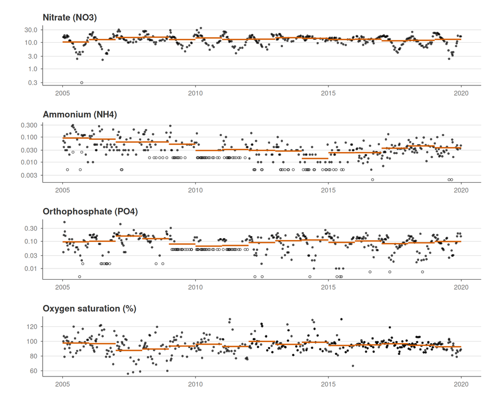

Samples (points; open: below the quantification limit, at half the limit) and yearly means (red lines) of the Loire at Montjean-sur-Loire, 2005–2019 (nutrients on a log scale).

```r
example <- river_kept$code_station[river_kept$libelle_station == "LOIRE à MONTJEAN-SUR-LOIRE"]
example_year <- tar_read(naiades_station_year) |>
  filter(code_station == example, between(year, 2005, 2019)) |>
  transmute(year, nitrate = 10^nitrate, ammonium = 10^ammonium, orthophosphate = 10^orthophosphate, river_oxygen = oxygen_saturation) |>
  tidyr::pivot_longer(-year, names_to = "nutrient", values_to = "value") |>
  mutate(start = as.Date(paste0(year, "-01-01")), end = as.Date(paste0(year, "-12-31")))
example_plot <- \(k, scale_y) {
  ggplot(filter(river_sample, code_station == example, nutrient == k), aes(date, value)) +
    geom_point(aes(shape = below_limit), size = 1.2, alpha = 0.7) +
    geom_segment(aes(x = start, xend = end, y = value, yend = value), data = filter(example_year, nutrient == k), color = "#D55E00", linewidth = 0.9) +
    scale_y +
    scale_shape_manual(values = c(`FALSE` = 16, `TRUE` = 1), guide = "none") +
    labs(x = NULL, y = NULL, title = input_label[[k]])
}
patchwork::wrap_plots(
  example_plot("nitrate", scale_y_log10()), example_plot("ammonium", scale_y_log10()),
  example_plot("orthophosphate", scale_y_log10()), example_plot("river_oxygen", scale_y_continuous()),
  ncol = 1
)
```

### Discharge: HYDRO gauging stations

HYDRO is the French national database of river discharge (gauging stations of the State services and their partners), read through the Hub’Eau hydrometry API (targets `hydrometry_station`, `hydrometry_discharge`): monthly mean discharge (m³/s) of the 3273 gauging stations draining to the estuaries, 2005–2019.

- **Yearly discharge:** mean of the 12 monthly means of a year (years with a missing month dropped).
- **Runoff:** discharge divided by the area drained at the gauge (l/s/km²). It lets a gauge upstream stand for the whole river: the discharge at the mouth is the runoff at the gauge times the catchment area of the mouth.

The same example, the Loire at Montjean-sur-Loire (drained area 110,147 km²):

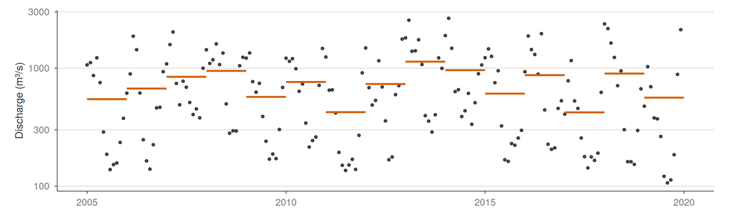

Monthly mean discharge (points) and yearly mean (red lines) of the Loire at Montjean-sur-Loire, 2005–2019 (log scale).

```r
discharge_month <- tar_read(hydrometry_discharge) |>
  filter(code_station == "M530001010")
discharge_year <- estuary_discharge$station_year |>
  filter(code_station == "M530001010") |>
  mutate(start = as.Date(paste0(year, "-01-01")), end = as.Date(paste0(year, "-12-31")))
ggplot(discharge_month, aes(date, discharge)) +
  geom_point(size = 1, alpha = 0.7) +
  geom_segment(aes(x = start, xend = end, y = discharge, yend = discharge), data = discharge_year, color = "#D55E00", linewidth = 0.9) +
  scale_y_log10() +
  labs(x = NULL, y = "Discharge (m³/s)")
```

### From the stations to the estuaries

Each estuary gets the yearly values of the rivers flowing into it (targets `estuary_nutrient_mix`, `mix_estuary_nutrient()`, and `estuary_discharge`, `summarise_estuary_discharge()`):

1. **Estuaries and their rivers:** the POMET zones are grouped into 29 estuaries (Gironde, Seine, Loire, the Breton estuaries, the bays…), and each estuary is given the mouths of the rivers flowing into it (one, or two for Morlaix, the Veys, Mont-Saint-Michel and the Pertuis Charentais; tables `pomet_estuary`, `pomet_estuary_mouth`, set by hand).
2. **Which stations drain to each mouth:** every NAIADES and gauging station follows the flow directions (HydroSHEDS grid, ~400 m, as in D15) downstream to the sea; the outlet it reaches gives its river mouth (`link_station_mouth()`). This also gives the area drained at the station.
3. **Eligible water quality stations:** outside the transitional and coastal water bodies of the WFD (200 m buffer), as a station there samples the estuary itself, with sea water mixed in, not what the rivers bring; and at least 10 yearly means in 2005–2019, the POMET years.
4. **One station per branch:** the eligible stations are taken from the largest drained area down, skipping those upstream of a station already taken (found along the flow directions). The stations kept are not nested: each samples a different branch reaching the estuary, the main river at its most downstream station and the tributaries and streams joining it below that station or entering the estuary directly.
5. **Weights:** the discharge of each branch, estimated as the area drained at the station times the yearly runoff of the gauging station on the same branch (upstream or downstream of it, closest drained area). Without a gauge on the branch, the runoff of the gauging stations of the estuary that year; without any gauge, the drained area alone.
6. **Mixing:** the yearly value of the estuary is the mean of its branches weighted by their discharge, computed on the concentrations (then log10): the concentration of the water of all the branches mixed together. A year is kept when the stations measured that year drain at least 80% of the area of all the stations kept (otherwise the value would jump with the stations present).
7. **Discharge of the estuary:** each year, each mouth takes the runoff of its most downstream gauging station measured that year (among those with at least 10 complete years), and the discharge of the estuary is their mean runoff (weighted by the catchment of the mouths) times the catchment area of the estuary.

Two examples. In the Gironde, the Garonne station is completed by the Dordogne and its tributaries (Isle, Dronne) and by smaller rivers joining the estuary; in the Seine, by the Eure, the Risle and the small rivers joining below the tidal limit (Poses dam). The stations inside the estuaries are left out.

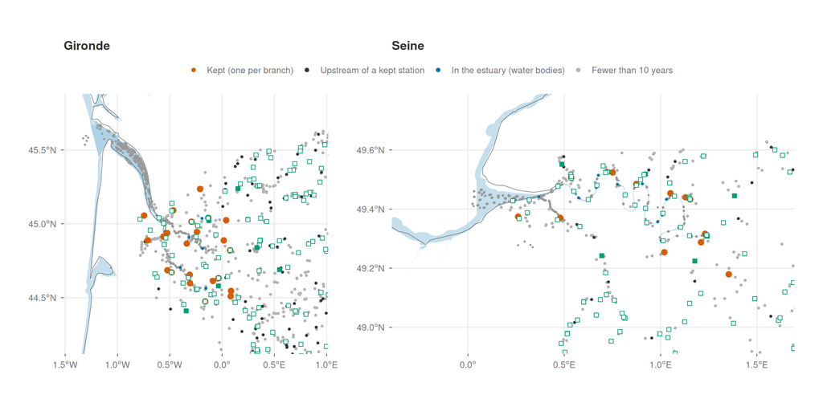

Water quality stations draining to the Gironde and Seine mouths, by why they are kept or not, gauging stations (squares; filled: giving the runoff of a kept station), and POMET operations (grey); blue: WFD transitional and coastal water bodies.

```r
as_water <- \(x) sf::st_sf(geometry = sf::st_geometry(sf::st_transform(x, 4326)))
water <- rbind(as_water(sf::st_read(tar_read(transitional_water_file), quiet = TRUE)), as_water(tar_read(coastal_water)))
colour_status <- c(kept = "#D55E00", `upstream of a kept station` = "grey20", `in the estuary` = "#0072B2", `too few years` = "grey70")
status_label <- c(
  kept = "Kept (one per branch)", `upstream of a kept station` = "Upstream of a kept station",
  `in the estuary` = "In the estuary (water bodies)", `too few years` = "Fewer than 10 years"
)
example_map <- \(e, xlim, ylim) {
  station <- filter(river_station, estuary == e) |>
    mutate(status = factor(status, rev(names(colour_status)))) |>
    arrange(status)
  gauge_e <- filter(gauge, estuary == e) |>
    mutate(used = code_station %in% river_mix$station$gauge)
  ggplot() +
    geom_sf(data = water, fill = "#9ECAE1", color = NA, alpha = 0.6) +
    geom_sf(data = coast, color = "grey30", linewidth = 0.2) +
    geom_point(aes(longitude, latitude), data = filter(estuary_visit, estuary == e), color = "grey60", size = 0.4) +
    geom_sf(aes(color = status, size = status == "kept"), data = station) +
    geom_sf(aes(fill = used), data = gauge_e, shape = 22, size = 2, color = "#009E73") +
    coord_sf(xlim = xlim, ylim = ylim) +
    scale_color_manual(values = colour_status, labels = status_label, breaks = names(colour_status), name = NULL) +
    scale_fill_manual(values = c(`TRUE` = "#009E73", `FALSE` = "white"), guide = "none") +
    scale_size_manual(values = c(`FALSE` = 0.8, `TRUE` = 2.5), guide = "none") +
    labs(x = NULL, y = NULL, title = e) +
    theme(axis.line = element_blank(), legend.position = "top")
}
patchwork::wrap_plots(
  example_map("Gironde", c(-1.4, 0.9), c(44.2, 45.8)),
  example_map("Seine", c(-0.3, 1.6), c(48.95, 49.75)),
  nrow = 1, guides = "collect"
) & theme(legend.position = "top")
```

All the estuaries, with the stations kept (triangles) linked to the operations of their estuary (centre of the operations):

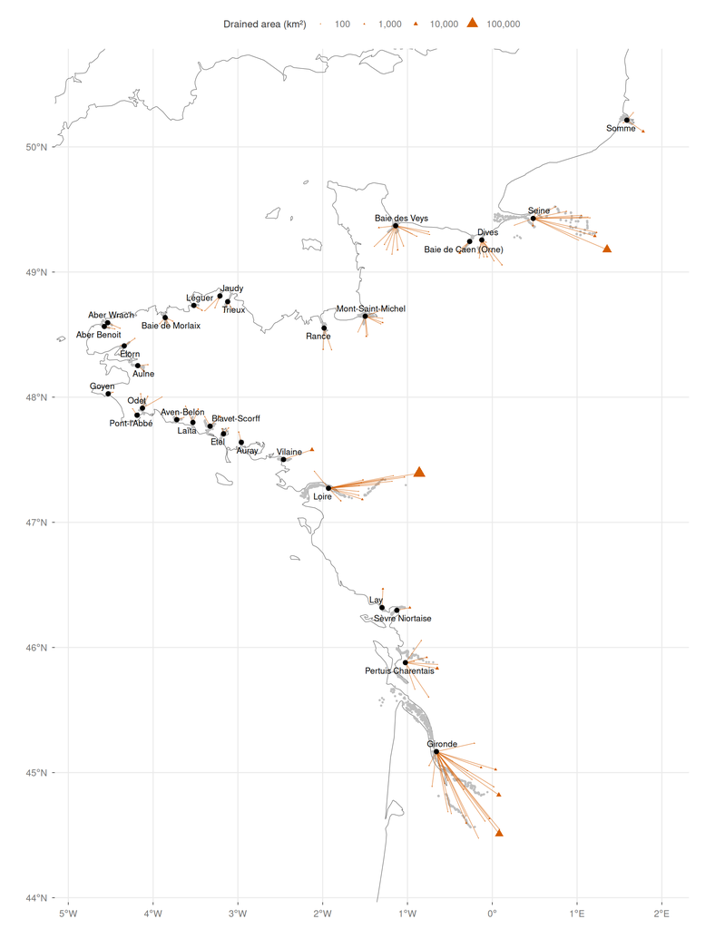

Water quality stations kept for each estuary (triangles, size: drained area), linked to the centre of the POMET operations of their estuary (circles); grey: operations.

```r
estuary_centre <- estuary_visit |>
  summarise(x_visit = mean(longitude), y_visit = mean(latitude), .by = estuary)
kept_xy <- river_kept |>
  mutate(x_station = sf::st_coordinates(geometry)[, 1], y_station = sf::st_coordinates(geometry)[, 2]) |>
  sf::st_drop_geometry() |>
  inner_join(estuary_centre, by = "estuary")
river_extent <- list(
  x = range(c(estuary_visit$longitude, kept_xy$x_station)) + c(-0.2, 0.2),
  y = range(c(estuary_visit$latitude, kept_xy$y_station)) + c(-0.2, 0.2)
)
ggplot() +
  geom_sf(data = coast, color = "grey30", linewidth = 0.2) +
  geom_point(aes(longitude, latitude), data = estuary_visit, color = "grey75", size = 0.4) +
  geom_segment(aes(x_station, y_station, xend = x_visit, yend = y_visit), data = kept_xy, color = "#D55E00", linewidth = 0.3, alpha = 0.6) +
  geom_point(aes(x_visit, y_visit), data = estuary_centre, size = 1.8) +
  geom_point(aes(x_station, y_station, size = area), data = kept_xy, shape = 17, color = "#D55E00") +
  ggrepel::geom_text_repel(aes(x_visit, y_visit, label = estuary), data = estuary_centre, size = 3, max.overlaps = Inf) +
  coord_sf(xlim = river_extent$x, ylim = river_extent$y) +
  scale_size_area(max_size = 4, breaks = c(100, 1000, 10000, 100000), labels = scales::label_comma(), name = "Drained area (km²)") +
  labs(x = NULL, y = NULL) +
  theme(axis.line = element_blank(), legend.position = "top")
```

```r
river_kept |>
  sf::st_drop_geometry() |>
  summarise(
    Stations = n(), `Share of the catchment` = sum(estuary_share),
    `Largest station` = libelle_station[which.max(area)],
    `Weight with a gauge on the branch` = sum(area[!is.na(gauge)]) / sum(area), .by = estuary
  ) |>
  left_join(
    summarise(estuary_discharge$station, `Discharge gauge share` = max(share), .by = estuary),
    by = "estuary"
  ) |>
  left_join(summarise(estuary_discharge$estuary_year, `Discharge (m³/s)` = mean(discharge), .by = estuary), by = "estuary") |>
  right_join(
    summarise(estuary_visit, Operations = n(), `With river inputs` = mean(!is.na(nitrate) & !is.na(discharge)), .by = estuary),
    by = "estuary"
  ) |>
  arrange(desc(Operations)) |>
  rename(Estuary = estuary) |>
  knitr::kable(digits = 2, caption = "River inputs of each estuary: water quality stations kept (one per branch), share of the catchment of the estuary they drain, their most downstream station, share of their drained area with a gauging station on the same branch; largest share of a mouth catchment drained at the discharge gauges, mean discharge 2005–2019; POMET operations and share with all the river inputs.")
```

River inputs of each estuary: water quality stations kept (one per branch), share of the catchment of the estuary they drain, their most downstream station, share of their drained area with a gauging station on the same branch; largest share of a mouth catchment drained at the discharge gauges, mean discharge 2005–2019; POMET operations and share with all the river inputs.

| Estuary | Stations | Share of the catchment | Largest station | Weight with a gauge on the branch | Discharge gauge share | Discharge (m³/s) | Operations | With river inputs |
| --- | --- | --- | --- | --- | --- | --- | --- | --- |
| Seine | 12 | 0.97 | LA SEINE A COURCELLES-SUR-SEINE 3 | 1.00 | 0.40 | 531.36 | 1101 | 0.93 |
| Gironde | 22 | 0.95 | La Garonne à Couthures | 0.98 | 0.63 | 803.61 | 642 | 0.87 |
| Blavet-Scorff | 2 | 0.89 | BLAVET à LANGUIDIC | 1.00 | 0.35 | 35.57 | 531 | 1.00 |
| Pertuis Charentais | 7 | 0.89 | La Charente à Taillebourg | 0.95 | 0.64 | 102.81 | 449 | 0.75 |
| Loire | 14 | 0.98 | LOIRE à MONTJEAN-SUR-LOIRE | 0.99 | 0.93 | 783.20 | 431 | 1.00 |
| Baie de Morlaix | 4 | 0.63 | R PENZE À TAULE | 0.13 | 0.66 | 9.71 | 273 | 0.91 |
| Laïta | 2 | 0.80 | ELLE à ARZANO | 1.00 | 0.21 | 22.85 | 267 | 1.00 |
| Mont-Saint-Michel | 7 | 0.81 | COUESNON à SOUGEAL (ANTRAIN) | 0.97 | 0.49 | 29.97 | 263 | 1.00 |
| Baie de Caen (Orne) | 2 | 0.92 | L’ORNE A LOUVIGNY 1 | 1.00 | 0.77 | 26.46 | 245 | 0.87 |
| Baie des Veys | 11 | 0.75 | LA VIRE A PONT-HEBERT 3 | 0.76 | 0.45 | 51.31 | 245 | 1.00 |
| Aven-Belon | 2 | 0.67 | AVEN à PONT-AVEN | 0.76 | 0.51 | 7.21 | 221 | 0.85 |
| Somme | 3 | 0.91 | LA SOMME CANALISÉE À CAMBRON (80) | 1.00 | 0.93 | 39.92 | 206 | 1.00 |
| Sèvre Niortaise | 1 | 0.89 | SEVRE NIORTAISE à MARANS | 1.00 | 0.28 | 21.64 | 153 | 1.00 |
| Aulne | 2 | 0.85 | AULNE à SAINT-SEGAL | 0.92 | 0.72 | 36.86 | 120 | 0.91 |
| Vilaine | 1 | 0.96 | VILAINE à RIEUX | 1.00 | 0.96 | 81.40 | 119 | 1.00 |
| Odet | 3 | 0.58 | ODET à QUIMPER | 1.00 | 0.29 | 15.63 | 103 | 0.49 |
| Rance | 2 | 0.70 | RANCE à SAINT-ANDRE-DES-EAUX | 0.67 | 0.13 | 9.36 | 92 | 1.00 |
| Goyen | 1 | 0.57 | GOYEN à PONT-CROIX | 0.00 | 0.57 | 2.70 | 85 | 1.00 |
| Pont-l’Abbé | 1 | 0.30 | RAU DE PONT L’ABBE à PLONEOUR-LANVERN | 1.00 | 0.30 | 2.04 | 85 | 1.00 |
| Dives | 9 | 0.82 | LA DIVES A BIEVILLE-QUETIEVILLE 1 | 0.69 | 0.35 | 9.41 | 84 | 1.00 |
| Trieux | 2 | 0.85 | TRIEUX à PLOUEC-DU-TRIEUX | 1.00 | 0.48 | 10.99 | 83 | 1.00 |
| Aber Benoit | 1 | 0.27 | ABER BENOIT à PLOUVIEN | 1.00 | 0.09 | 6.15 | 83 | 1.00 |
| Léguer | 2 | 0.89 | LEGUER à PLOUBEZRE | 0.90 | 0.35 | 13.74 | 82 | 1.00 |
| Jaudy | 2 | 0.50 | JAUDY à MANTALLOT | 0.22 | 0.39 | 4.52 | 81 | 1.00 |
| Lay | 1 | 0.77 | LAY à LA CLAYE | 1.00 | 0.47 | 18.64 | 76 | 1.00 |
| Élorn | 2 | 0.72 | ELORN à PLOUEDERN | 0.91 | 0.66 | 8.86 | 74 | 1.00 |
| Aber Wrac’h | 1 | 0.59 | ABER WRAC’H à LANARVILY | 1.00 | 0.25 | 2.00 | 65 | 1.00 |
| Auray | 1 | 0.49 | RAU D’AURAY ou LOC’H à BRECH | 0.00 | 0.49 | 5.55 | 56 | 1.00 |
| Etel | 2 | 0.32 | RAU DE LA DEMI VILLE à LANDEVANT | 0.00 | NA | NA | 49 | 0.00 |

### Values at the hauls

There is no extrapolation in space: each haul takes the values of its estuary in its year, and all the hauls of an estuary in a year share them, whatever their position or salinity. The dilution of river water along the estuary is left to salinity, already in the model.

The map shows the mean over 2005–2019 at each station kept (triangles) and the value the operations get after mixing (circles).

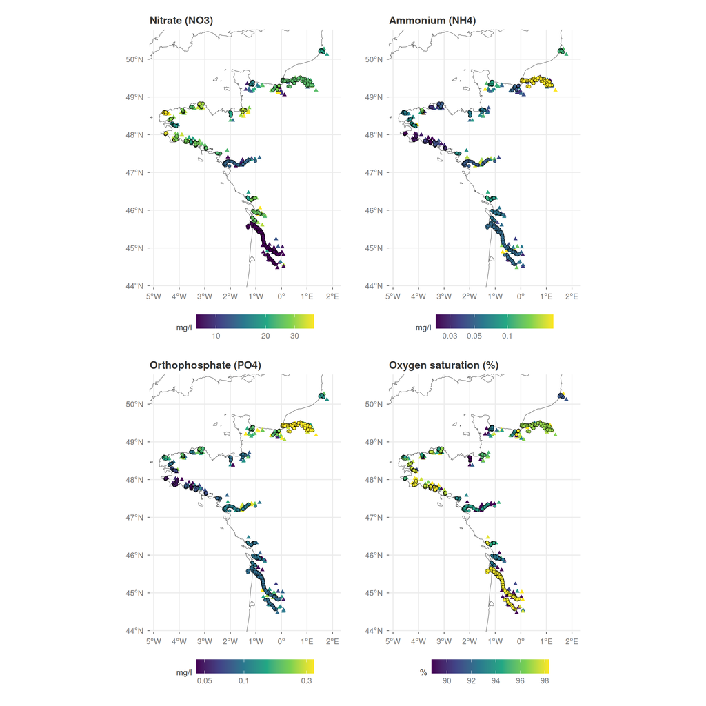

Mean 2005–2019 (geometric mean of the yearly means for nutrients) at the stations kept (triangles) and at the POMET operations of their estuary after mixing (circles, black outline; log colour scale for nutrients; the colour scale spans the estuary values, stations beyond it take its end colours).

```r
station_mean <- tar_read(naiades_station_year) |>
  filter(code_station %in% river_kept$code_station, between(year, 2005, 2019)) |>
  summarise(across(names(river_label), \(x) 10^mean(x)), river_oxygen = mean(oxygen_saturation), .by = code_station)
estuary_mean <- estuary_year |>
  summarise(across(names(river_label), \(x) 10^mean(x)), river_oxygen = mean(river_oxygen), discharge = mean(discharge), .by = estuary)
river_mean <- bind_rows(
  inner_join(select(estuary_visit, estuary, x = longitude, y = latitude), estuary_mean, by = "estuary") |> mutate(where = "operation"),
  inner_join(select(kept_xy, code_station, x = x_station, y = y_station), station_mean, by = "code_station") |> mutate(where = "station")
)
purrr::map(c(names(river_label), "river_oxygen"), \(k) {
  ggplot() +
    geom_sf(data = coast, color = "grey30", linewidth = 0.2) +
    geom_point(aes(x, y, color = .data[[k]]), data = filter(river_mean, where == "station"), shape = 17, size = 1.5) +
    geom_point(aes(x, y, fill = .data[[k]]), data = filter(river_mean, where == "operation"), shape = 21, size = 1.6, stroke = 0.2) +
    coord_sf(xlim = river_extent$x, ylim = river_extent$y) +
    scale_color_viridis_c(
      transform = if (k == "river_oxygen") "identity" else "log10", limits = range(estuary_mean[[k]]), oob = scales::squish,
      labels = scales::label_number(drop0trailing = TRUE), name = if (k == "river_oxygen") "%" else "mg/l",
      guide = guide_colorbar(barwidth = 10), aesthetics = c("color", "fill")
    ) +
    labs(x = NULL, y = NULL, title = input_label[[k]]) +
    theme(axis.line = element_blank(), legend.position = "bottom")
}) |>
  patchwork::wrap_plots(nrow = 2)
```

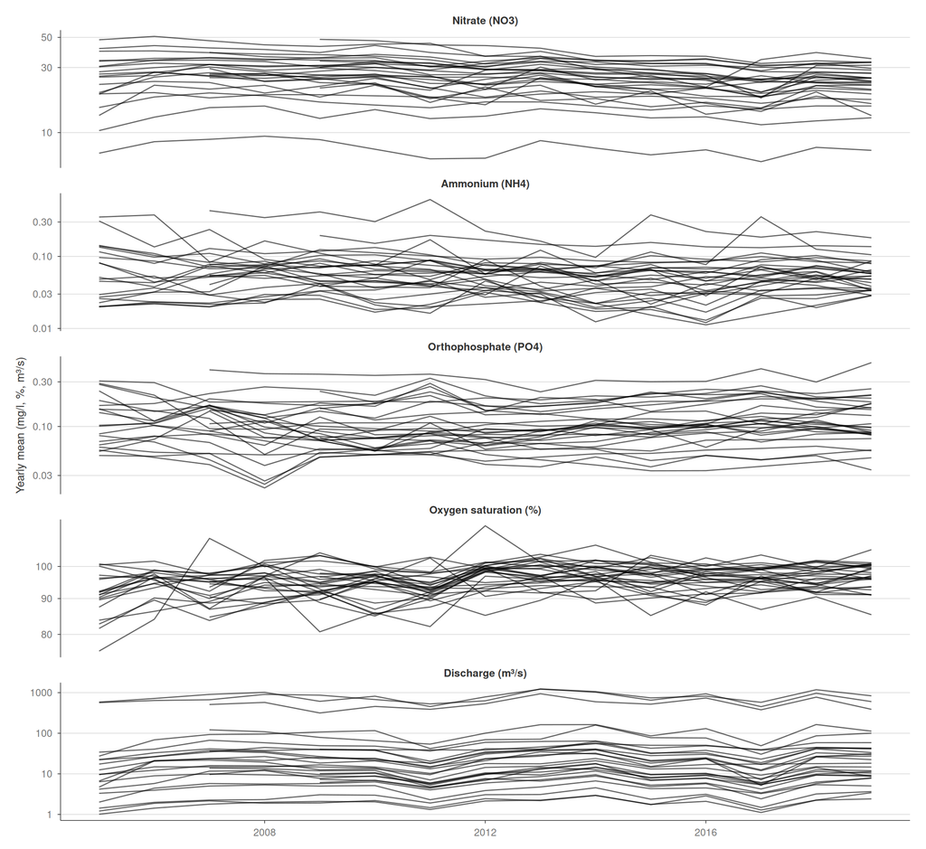

Yearly river inputs of each estuary (one line per estuary; log scale).

```r
estuary_year |>
  transmute(estuary, year, nitrate = 10^nitrate, ammonium = 10^ammonium, orthophosphate = 10^orthophosphate, river_oxygen, log_discharge = discharge) |>
  tidyr::pivot_longer(-c(estuary, year), names_to = "input", values_to = "value") |>
  mutate(input = factor(input_label[input], input_label)) |>
  ggplot(aes(year, value, group = estuary)) +
  geom_line(alpha = 0.6) +
  facet_wrap(~input, scales = "free_y", ncol = 1) +
  scale_y_continuous(transform = scales::transform_log10()) +
  labs(x = NULL, y = "Yearly mean (mg/l, %, m³/s)")
```

What a presence model with the spatial field can use is the variation of the inputs from year to year within an estuary, beyond the years shared by all estuaries (the year effect). The table splits the variance of the yearly values (estuary-years) into the differences between estuaries, the years shared by all estuaries, and what is left.

```r
river_variance <- purrr::map_dfr(names(input_label), \(k) {
  d <- mutate(estuary_year, log_discharge = log10(discharge))
  r2 <- \(f) summary(lm(f, d))$r.squared
  between <- r2(reformulate("estuary", k))
  shared <- r2(reformulate(c("estuary", "factor(year)"), k))
  tibble(
    Input = input_label[[k]], `Between estuaries` = between, `+ years shared by all estuaries` = shared,
    `Left: estuary-specific years` = 1 - shared,
    `Within-estuary sd` = sd(stats::resid(stats::lm(reformulate("estuary", k), d)))
  )
})
knitr::kable(river_variance, digits = 2, caption = "Share of the variance of the yearly values (estuary-years; log10 for nutrients and discharge) explained by the estuary, then by the year (cumulative R²), and standard deviation within estuaries (log10 units, or % for oxygen).")
```

Share of the variance of the yearly values (estuary-years; log10 for nutrients and discharge) explained by the estuary, then by the year (cumulative R²), and standard deviation within estuaries (log10 units, or % for oxygen).

| Input | Between estuaries | + years shared by all estuaries | Left: estuary-specific years | Within-estuary sd |
| --- | --- | --- | --- | --- |
| Nitrate (NO3) | 0.88 | 0.94 | 0.06 | 0.06 |
| Ammonium (NH4) | 0.76 | 0.80 | 0.20 | 0.14 |
| Orthophosphate (PO4) | 0.83 | 0.87 | 0.13 | 0.10 |
| Oxygen saturation (%) | 0.25 | 0.40 | 0.60 | 4.13 |
| Discharge (m³/s) | 0.96 | 0.99 | 0.01 | 0.14 |

**Results:**

*To discuss:*

- Yearly mean concentrations, not loads: discharge enters the model as its own variable, and as the weight of the branches within an estuary.
- Runoff from a gauge stands for the whole branch or catchment: right where rainfall and soils are similar along the river, less so for large basins (the Garonne gauge for the Gironde catchment) or where the gauge drains a small part of the catchment (Aber Benoit, Rance: about 10%).
- The Dives nitrate doubles from 2017 on (about 20–30 mg/l before, about 50 after, at its main station) and stays there: more likely a change of laboratory or of sampling point than a real change. Kept for now.

### Presence models with river inputs

Each nutrient is added, alone, to the reference model of the sole and the flounder (target `pomet_nutrient_model`), on the 5885 operations with river inputs; the reference model is refitted on the same operations for the WAIC comparison. The nutrient enters as a linear term of its log10 yearly value, standardised like the other variables (1 sd: a factor of 1.6 for nitrate, 2.3 for ammonium and 1.8 for phosphate across the operations). Two versions:

- **with the spatial field:** the field takes the differences between estuaries, so the effect rests on the estuary-specific years (a wetter or more polluted year in one estuary than its own average);
- **without the field:** the effect also rests on the differences between estuaries.

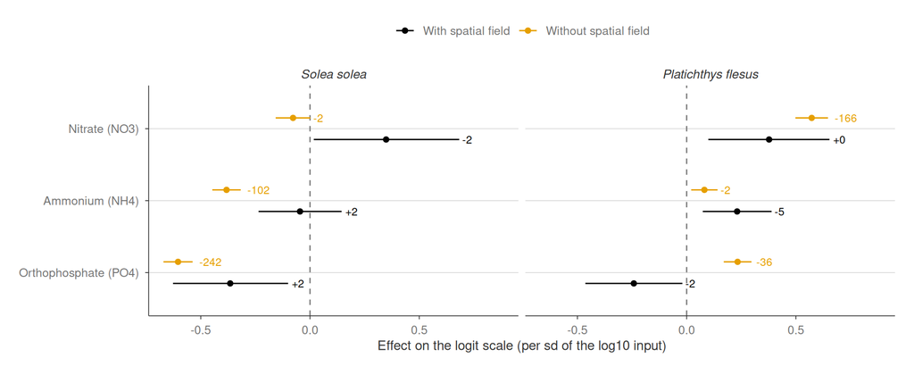

Effect of each river nutrient added alone to the reference model (logit scale, standardised, 91% credible intervals), with and without the spatial field. Labels: WAIC difference to the reference refitted on the same operations (negative: better).

```r
nutrient_model <- tar_read(pomet_nutrient_model)
nutrient_fit <- purrr::map_dfr(nutrient_model, \(m) {
  f <- m$summary.fixed
  tibble(
    species = m$species, nutrient = m$nutrient, field = !grepl("no field", m$variant), waic = m$waic,
    mean = if (m$nutrient == "none") NA else f[m$nutrient, "mean"],
    lower = if (m$nutrient == "none") NA else f[m$nutrient, "0.045quant"],
    upper = if (m$nutrient == "none") NA else f[m$nutrient, "0.955quant"]
  )
}) |>
  mutate(dwaic = waic - waic[nutrient == "none"], .by = c(species, field))
nutrient_fit |>
  filter(nutrient != "none") |>
  mutate(
    species = factor(species, test_species), nutrient = factor(river_label[nutrient], rev(river_label)),
    model = if_else(field, "With spatial field", "Without spatial field")
  ) |>
  ggplot(aes(mean, nutrient, color = model)) +
  geom_vline(xintercept = 0, linetype = "dashed", color = "grey50") +
  geom_pointrange(aes(xmin = lower, xmax = upper), size = 0.25, position = position_dodge(width = 0.6)) +
  geom_text(
    aes(x = upper, label = sprintf("%+.0f", dwaic)), position = position_dodge(width = 0.6),
    hjust = -0.3, size = 3, show.legend = FALSE
  ) +
  facet_wrap(~species) +
  scale_x_continuous(expand = expansion(mult = c(0.05, 0.2))) +
  scale_color_manual(values = c(`With spatial field` = "black", `Without spatial field` = "#E69F00")) +
  labs(x = "Effect on the logit scale (per sd of the log10 input)", y = NULL, color = NULL) +
  theme(strip.text = element_text(face = "italic"), legend.position = "top")
```

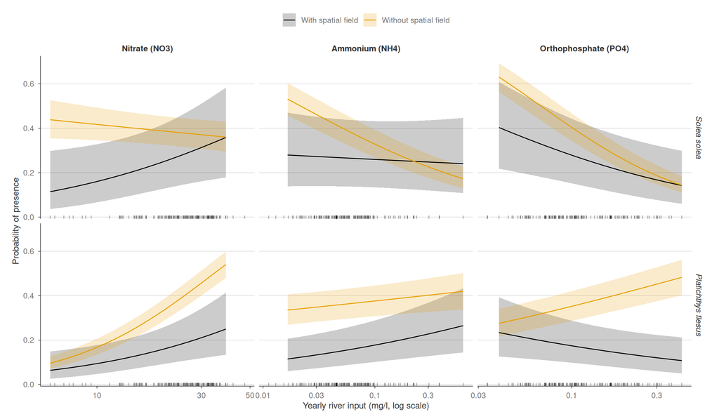

Probability of presence along the river input of the estuary (each nutrient alone in the reference model; 91% credible intervals), with and without the spatial field. Ticks: values at the operations.

```r
nutrient_curve <- purrr::map_dfr(nutrient_model, \(m) {
  if (m$nutrient == "none") return(NULL)
  random_mean <- mean(m$prediction$eta - m$prediction$eta_fixed)
  filter(m$curve, variable == m$nutrient) |>
    mutate(
      species = factor(m$species, test_species), model = if_else(grepl("no field", m$variant), "Without spatial field", "With spatial field"),
      across(c(mean, lower, upper), \(x) plogis(x + random_mean)), value = 10^value
    )
})
nutrient_rug <- tar_read(pomet_nutrient_visit) |>
  distinct(estuary, year, nitrate, ammonium, orthophosphate) |>
  tidyr::pivot_longer(names(river_label), names_to = "variable", values_to = "value") |>
  mutate(value = 10^value)
ggplot(nutrient_curve, aes(value, mean, color = model, fill = model)) +
  geom_ribbon(aes(ymin = lower, ymax = upper), alpha = 0.2, color = NA) +
  geom_line() +
  geom_rug(aes(value), data = nutrient_rug, inherit.aes = FALSE, alpha = 0.3, length = unit(0.02, "npc")) +
  facet_grid(species ~ factor(river_label[variable], river_label), scales = "free_x") +
  scale_x_log10(labels = scales::label_number(drop0trailing = TRUE)) +
  scale_color_manual(values = c(`With spatial field` = "black", `Without spatial field` = "#E69F00"), aesthetics = c("color", "fill")) +
  labs(x = "Yearly river input (mg/l, log scale)", y = "Probability of presence", color = NULL, fill = NULL) +
  theme(strip.text.y = element_text(face = "italic"), legend.position = "top")
```

**Results:**

- **With the field (the baseline), the river inputs add little.** Only ammonium for the flounder improves the model by a few points (-5.2 WAIC points); the other nutrients change the WAIC by about 2 points. Several effects are credible without improving the fit: more sole and flounder with more nitrate, fewer with more phosphate.
- **Without the field, the differences between estuaries carry strong effects:** fewer sole in the estuaries receiving more phosphate (-242 WAIC points) or ammonium, and more flounder in the estuaries receiving more nitrate (-166). These models remain far worse than those with the field (by 1638 WAIC points or more).
- The two versions disagree for several nutrients (e.g. the flounder and phosphate: opposite signs): the next section separates the two contrasts.

### Between and within estuaries

The two versions above mix two contrasts. Here each river input is split in two (target `pomet_split_model`):

- **between:** the mean of the estuary over 2005–2019, the same for all its operations;
- **within:** the deviation of the year from that mean.

Both enter the model together, with an iid **estuary effect**, so that the between effect is estimated from the estuaries with an uncertainty that accounts for their number (in the model without field above, it rested on the operations as if they were independent). Each input is fitted alone, then with discharge (also split), since a wet year changes both the concentrations and the volume of river water; and each with and without the spatial field.

To compare the two parts, the effects are given per doubling of the nutrient input or of discharge, and per 10 points of oxygen saturation (log odds).

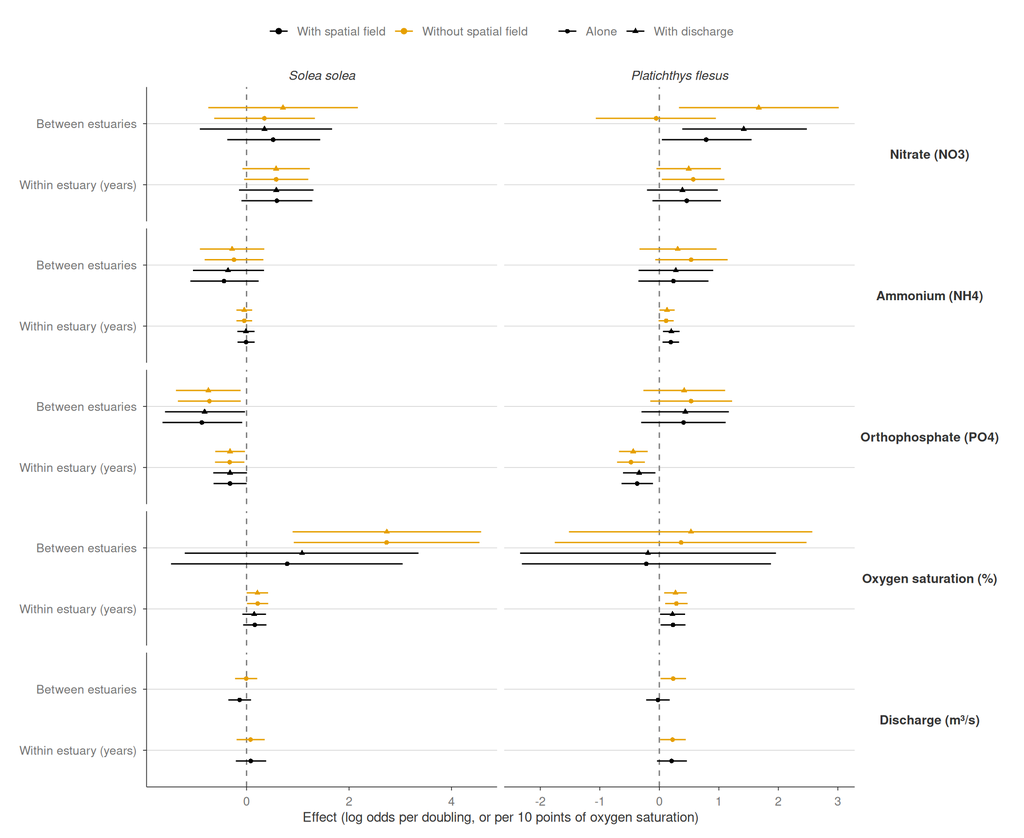

Effect of the between-estuary (estuary mean) and within-estuary (yearly deviation) parts of each river input, fitted together with an iid estuary effect, alone (circles) or with discharge (triangles), with and without the spatial field (log odds per doubling of the nutrient or discharge, per 10 points of oxygen saturation; 91% credible intervals).

```r
split_model <- tar_read(pomet_split_model)
split_visit <- tar_read(pomet_nutrient_visit)
input_unit <- c(nitrate = log10(2), ammonium = log10(2), orthophosphate = log10(2), river_oxygen = 10, log_discharge = log10(2))
split_fit <- purrr::map_dfr(split_model, \(m) {
  term <- grep("_(between|within)$", rownames(m$summary.fixed), value = TRUE)
  variable <- sub("_(between|within)$", "", term)
  tibble(
    species = m$species, input = m$input, field = m$field, waic = m$waic,
    variable = variable, part = sub(".*_", "", term),
    scale = input_unit[variable] / purrr::map_dbl(term, \(v) sd(split_visit[[v]])),
    mean = m$summary.fixed[term, "mean"], lower = m$summary.fixed[term, "0.045quant"], upper = m$summary.fixed[term, "0.955quant"]
  ) |>
    bind_rows(if (length(term) == 0) tibble(species = m$species, input = m$input, field = m$field, waic = m$waic) else NULL)
}) |>
  mutate(dwaic = waic - waic[input == "none"][1], .by = c(species, field)) |>
  mutate(
    across(c(mean, lower, upper), \(x) x * scale),
    adjusted = if_else(grepl("\\+ log_discharge", input), "With discharge", "Alone"),
    model = if_else(field, "With spatial field", "Without spatial field")
  )
split_effect <- split_fit |>
  filter(input != "none", !(adjusted == "With discharge" & variable == "log_discharge")) |>
  mutate(
    species = factor(species, test_species), variable = factor(input_label[variable], input_label),
    part = factor(if_else(part == "between", "Between estuaries", "Within estuary (years)"), c("Within estuary (years)", "Between estuaries")),
    group = paste(model, adjusted)
  )
ggplot(split_effect, aes(mean, part, color = model, shape = adjusted, group = group)) +
  geom_vline(xintercept = 0, linetype = "dashed", color = "grey50") +
  geom_pointrange(aes(xmin = lower, xmax = upper), size = 0.25, position = position_dodge(width = 0.7)) +
  facet_grid(variable ~ species, scales = "free_x") +
  scale_color_manual(values = c(`With spatial field` = "black", `Without spatial field` = "#E69F00")) +
  scale_shape_manual(values = c(Alone = 16, `With discharge` = 17)) +
  labs(x = "Effect (log odds per doubling, or per 10 points of oxygen saturation)", y = NULL, color = NULL, shape = NULL) +
  theme(strip.text.x = element_text(face = "italic"), strip.text.y = element_text(angle = 0), legend.position = "top")
```

```r
split_fit |>
  filter(input != "none") |>
  distinct(species, input, model, dwaic) |>
  mutate(
    Input = sub(" \\+ .*", "", input),
    Input = paste0(input_label[Input], if_else(grepl("\\+ log_discharge", input), " + discharge", ""))
  ) |>
  mutate(column = paste0(model, ", ", sub("(\\w)\\w+ (\\w+)", "\\1. \\2", species))) |>
  select(Input, column, dwaic) |>
  tidyr::pivot_wider(names_from = column, values_from = dwaic) |>
  knitr::kable(digits = 1, caption = "WAIC difference to the model with the estuary effect and no river input, on the same operations (negative: better).")
```

WAIC difference to the model with the estuary effect and no river input, on the same operations (negative: better).

| Input | With spatial field, S. solea | Without spatial field, S. solea | With spatial field, P. flesus | Without spatial field, P. flesus |
| --- | --- | --- | --- | --- |
| Discharge (m³/s) | -0.1 | 1.0 | -0.8 | -2.4 |
| Nitrate (NO3) | -1.0 | -0.8 | 0.4 | 0.3 |
| Ammonium (NH4) | 1.5 | 1.7 | -5.0 | -1.7 |
| Orthophosphate (PO4) | 0.9 | 0.1 | -1.2 | -6.6 |
| Oxygen saturation (%) | 1.9 | -0.7 | -1.3 | -3.9 |
| Nitrate (NO3) + discharge | 0.2 | 0.6 | -0.9 | -0.8 |
| Ammonium (NH4) + discharge | 1.7 | 2.6 | -5.7 | -3.4 |
| Orthophosphate (PO4) + discharge | 1.0 | 1.4 | -1.1 | -7.4 |
| Oxygen saturation (%) + discharge | 1.9 | 0.6 | -2.2 | -5.9 |

```r
split_waic <- purrr::map_dfr(split_model, \(m) tibble(species = m$species, input = m$input, field = m$field, waic = m$waic)) |>
  filter(input == "none") |>
  summarise(gain = waic[!field] - waic[field], .by = species)
```

**Results:**

- **The WAIC differences are small** (a few points at most): no river input clearly improves the models. The largest gains are for the flounder: ammonium with the field, phosphate and oxygen without it.
- **Within estuaries (years),** the flounder is less frequent in the years when its estuary receives more phosphate than its average and more frequent in years of more oxygenated river water (credible with and without the field), and more frequent in years of more ammonium (credible with the field, at the limit without it). These effects stay the same with discharge in the model. For the sole, phosphate (fewer sole; at the limit with the field) and oxygen (more sole; without the field only).
- **Between estuaries,** with the uncertainty of the estuaries, most effects include 0. Credible: fewer sole in the estuaries receiving more phosphate (with and without the field), more sole in those with more oxygenated rivers (without the field), and more flounder in those receiving more nitrate (with the field, and without it once discharge is in the model).
- **Discharge** has no credible effect on the sole. Without the field, the flounder is more frequent in larger rivers and in wetter years. **Adding discharge does not improve the models:** alone or on top of a nutrient or oxygen, it changes the WAIC by about 2 points at most (slightly worse for the sole, slightly better for the flounder). Its use is elsewhere: the within-estuary effects of the nutrients and oxygen keep the same size with it, so they are not wet-year effects, and it weights the branches when the stations are mixed.
- The spatial field still improves the model by 478 (sole) and 646 (flounder) WAIC points over the estuary effect alone: the differences within estuaries (along the estuary, between its zones) matter beyond the estuary level.

*To discuss:*

## Next steps

- One contrasting species per guild, then all the frequent species, with the baseline and the river inputs.
- D21: extend the model to the nursery survey of the coastal bays (salinity and temperature from the yearly grid or REPHY, no measured depth).
- Spatial cross-validation (one estuary left out at a time), the only way to test the between-estuary effects that the field hides.

## References

Elliott, Michael, and Victor Quintino. 2007. “The Estuarine Quality Paradox, Environmental Homeostasis and the Difficulty of Detecting Anthropogenic Stress in Naturally Stressed Areas.” *Marine Pollution Bulletin* 54 (6): 640–45. https://doi.org/10.1016/j.marpolbul.2007.02.003.